# David Marshall - Websocket Challenge

## Websocket - Wikipedia Edits

### 1. Introduction

Attempt to pull data through a web socket and then preprocess + analyse. The main bulk of analysis will focus on whether we can trust what we read on wikipedia, and what that suggests about what we read online. I will do this through examining both the edits themselves and the editors making the editions.

First, import some packages:

```python
from io import StringIO
import pandas as pd
import numpy as np
import json
import websocket
import time
from websocket import create_connection
import matplotlib.pyplot as plt
import seaborn as sns
import geopandas
from matplotlib import rcParams
import datetime
import timezonefinder, pytz
pd.options.mode.chained_assignment = None
from timezonefinder import TimezoneFinder
from wordcloud import WordCloud, STOPWORDS, ImageColorGenerator
import string
import nltk
import missingno as msno
pd.options.mode.chained_assignment = None
```

Next, define some helpful functions for visualisations:

```python
def countplot(var, data):
    total = len(data[var])
    g = sns.countplot(x = var, data = data,order=data[var].value_counts().iloc[:20].index)
    if len(data[var].unique()) <= 10:
        for p in g.patches:
            percentage = '{:.1f}%'.format(100 * p.get_height()/total)
            x = p.get_x() + p.get_width() / 2 - 0.05
            y = p.get_y() + p.get_height()
            g.annotate(percentage, (x, y), size = 12)
    plt.xlabel('Categories')
    plt.ylabel('Count')
    plt.title(f'countplot: {var}')
    if len(data[var].unique()) > 5:
        plt.xticks(rotation=90)
    plt.show()

def outlier_box(df,col):
    g = sns.boxplot(data =  df[col], orient = 'h', palette = 'Set3')
    g.set_title('Detecting Outliers')
    plt.ylabel(col)
    plt.show()

def geo_plot(dat, h = None,t = 'Where are wikipedia edits being made?', s = 100):
    ax = world_map.plot(color = 'black', edgecolor = 'white')
    ax.set_facecolor('xkcd:white')
    g = sns.scatterplot(x = 'geo_ip.longitude',
                        y = 'geo_ip.latitude',
                        data = dat, hue = h,
                       s = s,
                       linewidth = 0, ax = ax)
    g.set_title(t)
    g.tick_params(bottom = False, left = False)
    g.axis('off')
    g.set(xticklabels=[])
    g.set(yticklabels=[])
    plt.show()

def plot_hist(var, lab1,lab2, min_size = -1000, max_size = 1000):
    plot_data = df[(df['change_size'] != 0)]
    plot_data['change_size'] = np.clip(plot_data['change_size'],a_min = min_size, a_max = max_size)
    plt.hist(plot_data[plot_data[var] == True]['change_size'], bins = 30, alpha = 0.4, label = lab1)
    plt.hist(plot_data[plot_data[var] == False]['change_size'], bins = 30, alpha = 0.4, label = lab2)
    plt.xlabel('Change Size')
    plt.ylabel('Number of edits', size = 12)
    plt.legend(loc = 'upper left')
    plt.show()

def create_wordcloud():
    wordcloud = WordCloud(stopwords = stopwords, background_color = 'white',
             width = 800, height = 400).generate(' '.join(text_data))
    plt.axis('off')
    plt.figure(figsize = (40,20))
    plt.tight_layout(pad = 0)
    plt.imshow(wordcloud, interpolation = 'bilinear')
    plt.show()
```

### 2. Streaming

Stream and view 1 record by opening, recieving and then closing the connection:

```python
ws = create_connection("ws://wikimon.hatnote.com:9000")
result = ws.recv()
print(result)
ws.close()
```

```
{"action": "edit", "change_size": 5, "flags": "M", "hashtags": [], "is_anon": false, "is_bot": false, "is_minor": true, "is_new": false, "is_unpatrolled": false, "mentions": [], "ns": "Main", "page_title": "Phrygian language", "parent_rev_id": "1032935057", "parsed_summary": "one more wikilink", "re…
```

We can turn this into a data frame and view it:

```python
sample = pd.json_normalize(json.loads(result))
sample
```

|  | action | change_size | flags | hashtags | is_anon | is_bot | is_minor | is_new | is_unpatrolled | mentions | ns | page_title | parent_rev_id | parsed_summary | rev_id | section | summary | url | user |
| --- | --- | --- | --- | --- | --- | --- | --- | --- | --- | --- | --- | --- | --- | --- | --- | --- | --- | --- | --- |
| 0 | edit | 5 | M | [] | False | False | True | False | False | [] | Main | Phrygian language | 1032935057 | one more wikilink | 1032934675 | Pronomina | /* Pronomina */ one more wikilink | https://en.wikipedia.org/w/index.php?diff=1032... | Hans van Deukeren |

The records we are loading are an instance:

```python
isinstance(json.loads(result), dict)
```

```
True
```

We can put this together by adding records to a df provided we can read them. Stream data for an hour, add edit time and then save:

```python
df = pd.DataFrame()

ws = create_connection("ws://wikimon.hatnote.com:9000")

timeout = time.time() + 3600*1
while time.time() < timeout:
    js = json.loads(ws.recv())
    js['edit_time'] = datetime.datetime.now()
    if isinstance(js, dict):
        df = pd.concat([df, pd.json_normalize(js)])
    else:
        assert "Unknown Data"
    time.sleep(1)
df.to_csv('websocket_stream.csv', index = False)
print('Data Saved')
```

```
Data Saved
```

And view the top 5 rows:

```python
pd.set_option('display.max_columns', 50)
df = pd.read_csv('websocket_stream.csv')
df.head()
```

|  | action | change_size | flags | hashtags | is_anon | is_bot | is_minor | is_new | is_unpatrolled | mentions | ns | page_title | parent_rev_id | parsed_summary | rev_id | section | summary | url | user | edit_time | geo_ip.city | geo_ip.country_name | geo_ip.latitude | geo_ip.longitude | geo_ip.region_name |
| --- | --- | --- | --- | --- | --- | --- | --- | --- | --- | --- | --- | --- | --- | --- | --- | --- | --- | --- | --- | --- | --- | --- | --- | --- | --- |
| 0 | edit | 8.0 | NaN | [] | True | False | False | False | False | [] | Main | José Abad Santos | 1.032755e+09 | NaN | 1.030822e+09 | NaN | NaN | https://en.wikipedia.org/w/index.php?diff=1032... | 124.104.1.75 | 2021-07-09 14:07:23.360316 | Meycauayan | Philippines | 14.7069 | 120.93 | Central Luzon |
| 1 | edit | 20.0 | NaN | [] | False | False | False | False | False | [] | Main | 2021 Wimbledon Championships – Boys' Singles | 1.032755e+09 | NaN | 1.032746e+09 | Section 1 | /* Section 1 */ | https://en.wikipedia.org/w/index.php?diff=1032... | Tom111290 | 2021-07-09 14:07:24.373553 | NaN | NaN | NaN | NaN | NaN |
| 2 | edit | 68.0 | B | [] | False | True | False | False | False | [] | Project | Wikipedia:WikiProject U.S. Roads/Arkansas/Popu... | 1.032755e+09 | Popular pages report update | 1.027514e+09 | NaN | Popular pages report update | https://en.wikipedia.org/w/index.php?diff=1032... | Community Tech bot | 2021-07-09 14:07:25.391797 | NaN | NaN | NaN | NaN | NaN |
| 3 | edit | 441.0 | NaN | ['WikiSAU'] | False | False | False | False | False | [] | Main | Julius Okojie | 1.032755e+09 | added citations #WikiSAU | 1.032754e+09 | NaN | added citations #WikiSAU | https://en.wikipedia.org/w/index.php?diff=1032... | Joseph Agbeja | 2021-07-09 14:07:26.413098 | NaN | NaN | NaN | NaN | NaN |
| 4 | edit | 46.0 | NaN | [] | False | False | False | False | False | [] | Main | Mrs. Brown, You've Got a Lovely Daughter (film) | 1.032755e+09 | NaN | 1.032755e+09 | External links | /* External links */ | https://en.wikipedia.org/w/index.php?diff=1032... | Lord Cornwallis | 2021-07-09 14:07:27.424916 | NaN | NaN | NaN | NaN | NaN |

### 3. Data Summary

How many rows have I got, and what type are the columns?

```python
print('Shape of Data: ', df.shape)
```

```
Shape of Data:  (3542, 25)
```

```python
df.info()
```

```
<class 'pandas.core.frame.DataFrame'>
RangeIndex: 3542 entries, 0 to 3541
Data columns (total 25 columns):
 #   Column               Non-Null Count  Dtype
---  ------               --------------  -----
 0   action               3542 non-null   object
 1   change_size          3201 non-null   float64
 2   flags                800 non-null    object
 3   hashtags             3542 non-null   object
 4   is_anon              3542 non-null   bool
 5   is_bot               3542 non-null   bool
 6   is_minor             3542 non-null   bool
 7   is_new               3542 non-null   bool
 8   is_unpatrolled       3542 non-null   bool
 9   mentions             3542 non-null   object
```

[output cut: 17 more lines]

I have a few numeric and boolean fields, but mostly objects, most of which is relatively useless from an analysis perspective. To start with, let's view the distrubtion of the boolean and categorical variables:

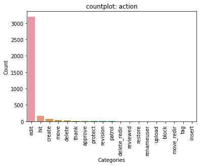

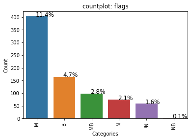

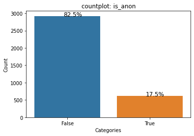

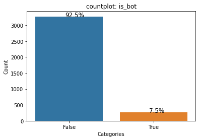

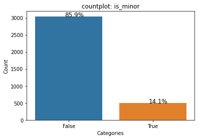

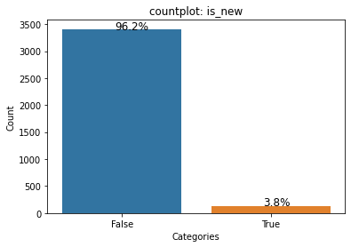

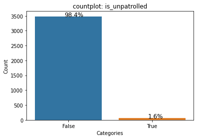

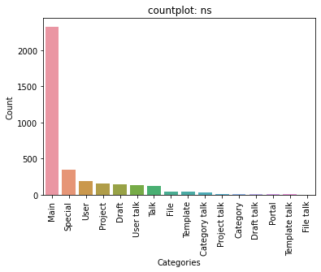

```python
for v in ['action', 'flags', 'is_anon', 'is_bot', 'is_minor', 'is_new', 'is_unpatrolled', 'ns']:
    countplot(v, df)
```

Most of the changes appear to be large edits to existing main pages made by people (not bots) with registered usernames. I think this bodes well for the general validity of the data. Next, some correlations of boolean and numeric:

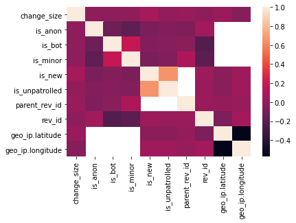

```python
corr = df.corr()
sns.heatmap(corr)
```

### 4. Missing Data

Next, I use a handy library *missingno* to visualise the missing data I have:

```python
df.isnull().sum()
```

```
action                    0
change_size             341
flags                  2742
hashtags                  0
is_anon                   0
is_bot                    0
is_minor                  0
is_new                    0
is_unpatrolled            0
mentions                  0
ns                        0
page_title                0
parent_rev_id           475
parsed_summary         1406
rev_id                  341
section                2349
summary                 685
url                     341
user                      0
edit_time                 0
geo_ip.city            3012
geo_ip.country_name    2923
geo_ip.latitude        2923
geo_ip.longitude       2923
geo_ip.region_name     3029
dtype: int64
```

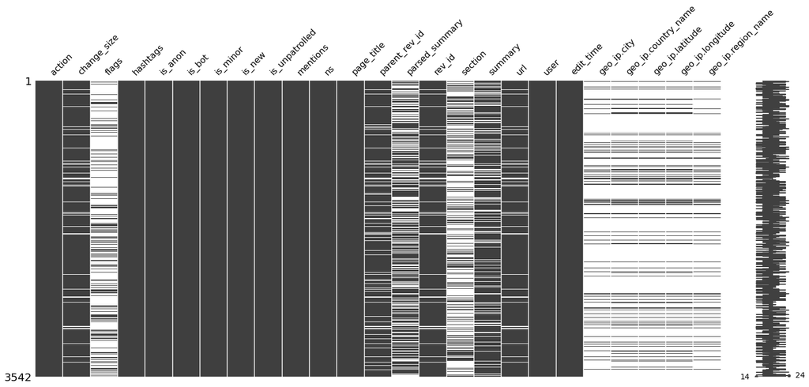

```python
msno.matrix(df)
```

It seems that there are a few key columns where I have complete information, and quite a lot where I do not. The flag and geo features seem to be particularly sparse. I think there could still be interesting information in these columns so I'm not going to drop them. It seems like if we have 1 geo feature for an edit we are likely to see them all. Check by looking at correlation of missingness:

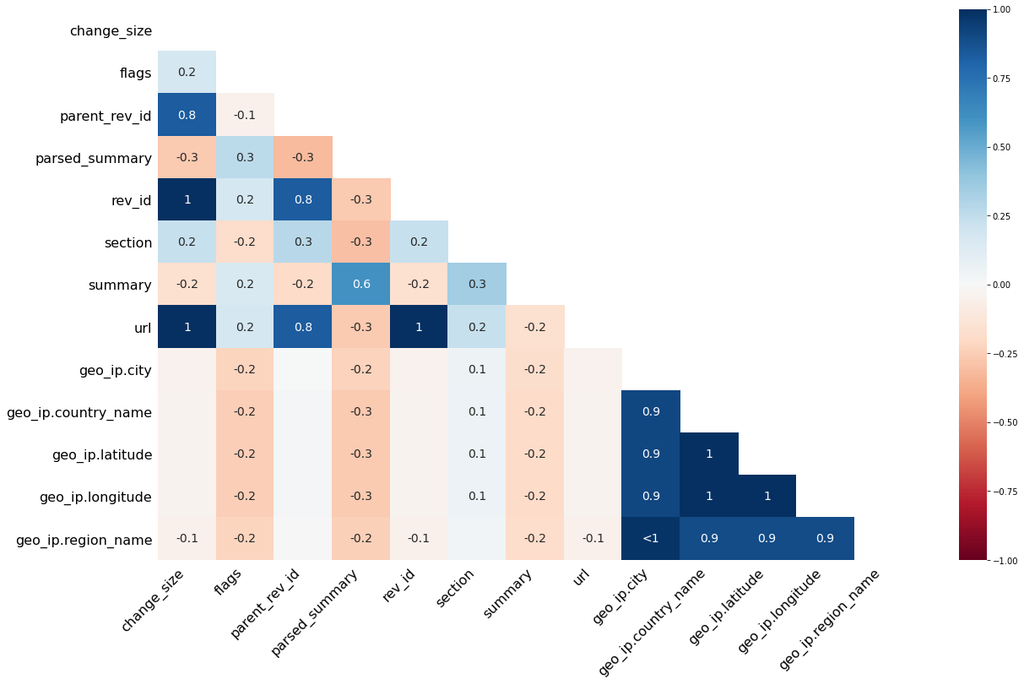

```python
msno.heatmap(df)
```

Yep, it seems there are correlations in particular for the geo features. There is little point in imputing the missing data since there is so much of it for the columns which have missing data.

### 5. Outliers

Next I want to briefly visualise any outliers for the numeric variables I have.

```python
print('Numeric Columns:',df.select_dtypes(include=np.number).columns.tolist())
```

```
Numeric Columns: ['change_size', 'parent_rev_id', 'rev_id', 'geo_ip.latitude', 'geo_ip.longitude']
```

2 of them look like ids which are not relevant for analysis. Boxplots of the other 3:

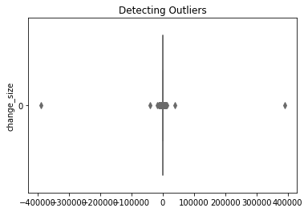

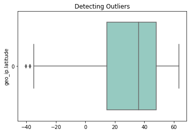

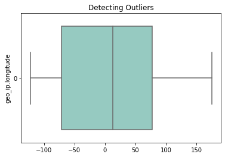

```python
for c in ['change_size', 'geo_ip.latitude', 'geo_ip.longitude']:
    outlier_box(df, c)
```

There are a couple of outliers for the geographic feautures but they still look to be in reasonable range. There are clear large outliers for the change size, with in some cases 400,000 characters changed. Since I think this likely to be automatically generated data by wikipedia when the edit is made I think it is accurate, so I will leave them in there but be mindful when analysing.

### 6. Change Size

Next, I want to explore change size as that seems like an important feature. Generally, we would expect large changes to be *is_minor=False*, not made by bots and made by users with names (as they are more likely to be trusted editors).

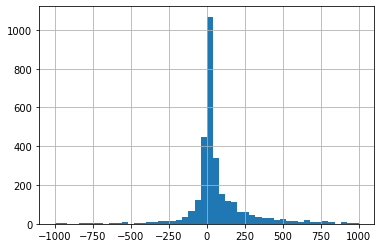

```python
df['change_size'].hist(bins = 50, range = (-1000,1000))
```

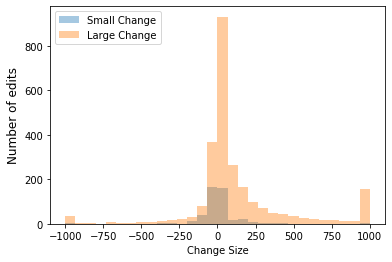

```python
plot_hist(var = 'is_minor',lab1 = 'Small Change', lab2 = 'Large Change')
```

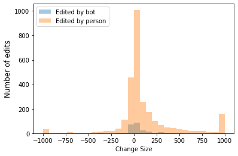

```python
plot_hist(var = 'is_bot',lab1 = 'Edited by bot', lab2 = 'Edited by person')
```

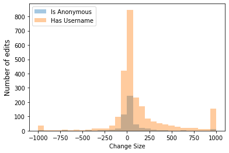

```python
plot_hist(var = 'is_anon',lab1 = 'Is Anonymous', lab2 = 'Has Username')
```

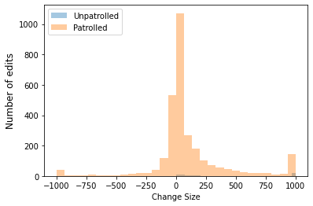

```python
plot_hist(var = 'is_unpatrolled',lab1 = 'Unpatrolled', lab2 = 'Patrolled')
```

I think we can conclude that generally the information is reliable because larger changes are normally set to *major*, they are made by people with usernames and are *patrolled*.

### 7. Geo Features

The geo feautures are likely related to the place where the edit is being made and the editors themselves. While I only have it for ~20% of edits, I think it likely useful info. First, some count plots:

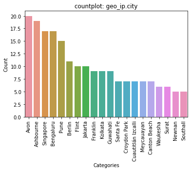

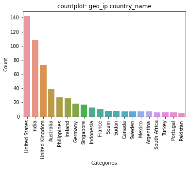

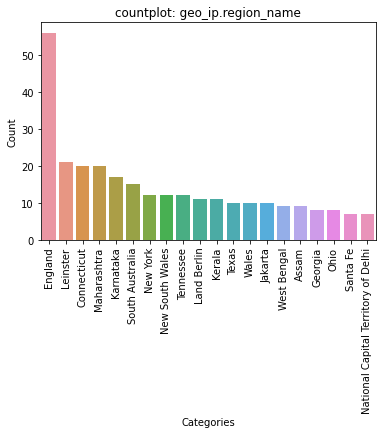

```python
for v in ['geo_ip.city', 'geo_ip.country_name', 'geo_ip.region_name']:
    countplot(v, df)
```

Next, view them on a map of the world. Map downloaded from the world bank: https://datacatalog.worldbank.org/dataset/world-bank-official-boundaries

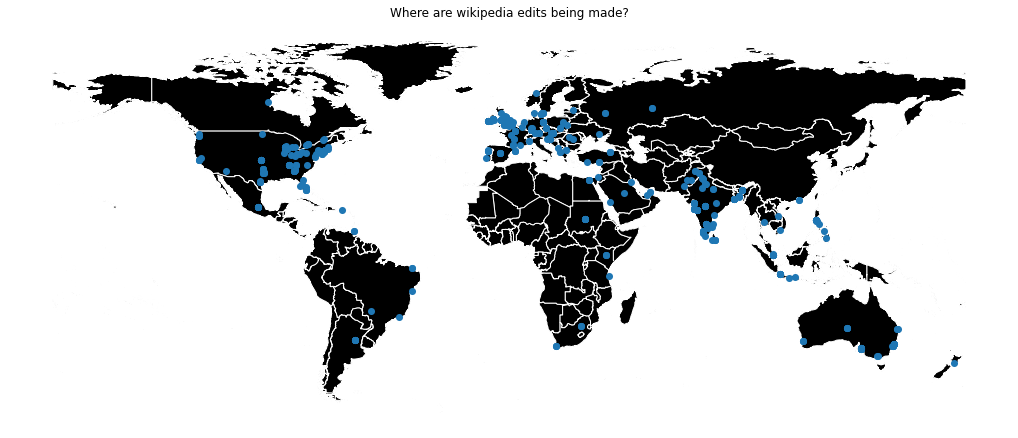

```python
# Load world map
world_map = geopandas.read_file('WB_countries_Admin0_10m/WB_countries_Admin0_10m.shp')

# Switch to long/lat
world_map = world_map.to_crs(epsg = 4326)

# Plot
rcParams['figure.figsize'] = 18,10
geo_plot(df, s = 50)
```

First observation is that all the points look reasonable - none of them appear to be in the sea. Next, I want to explore the local time that these edits are being made:

```python
# Time zones
my_func = TimezoneFinder().timezone_at

# Define new df of geo features only
tz_df = df[~df['geo_ip.latitude'].isnull()]

# Add timezone for each location
tz_df['timezone'] = tz_df.apply(lambda x : my_func(lat = x[ 'geo_ip.latitude'],
                                             lng = x['geo_ip.longitude']), axis = 1)

# Convert edit time to datetime format
tz_df['edit_time'] = pd.to_datetime(tz_df['edit_time'])

# Convert time to local using timezone
tz_df['local_edit_time'] = (pd.to_datetime(tz_df.groupby('timezone')['edit_time']\
                            .transform(lambda x: x.dt.tz_localize('UTC').dt.tz_convert(x.name))\
                            .astype(str).str[:-6]))

# Take hour of the day from new time
tz_df['hour'] = tz_df['local_edit_time'].astype(str).str.slice(11,13).astype(int)

# View
tz_df.iloc[:,19:].head()
```

|  | edit_time | geo_ip.city | geo_ip.country_name | geo_ip.latitude | geo_ip.longitude | geo_ip.region_name | timezone | local_edit_time | hour |
| --- | --- | --- | --- | --- | --- | --- | --- | --- | --- |
| 0 | 2021-07-09 14:07:23.360316 | Meycauayan | Philippines | 14.7069 | 120.9300 | Central Luzon | Asia/Manila | 2021-07-09 22:07:23.360316 | 22 |
| 7 | 2021-07-09 14:07:30.465804 | Zagreb | Croatia | 45.8293 | 15.9793 | City of Zagreb | Europe/Zagreb | 2021-07-09 16:07:30.465804 | 16 |
| 8 | 2021-07-09 14:07:31.470816 | Zagreb | Croatia | 45.8293 | 15.9793 | City of Zagreb | Europe/Zagreb | 2021-07-09 16:07:31.470816 | 16 |
| 12 | 2021-07-09 14:07:35.486183 | Uttoxeter | United Kingdom | 52.8755 | -1.8024 | England | Europe/London | 2021-07-09 15:07:35.486183 | 15 |
| 16 | 2021-07-09 14:07:39.504198 | Dallas | United States | 32.8756 | -96.7495 | Texas | America/Chicago | 2021-07-09 09:07:39.504198 | 9 |

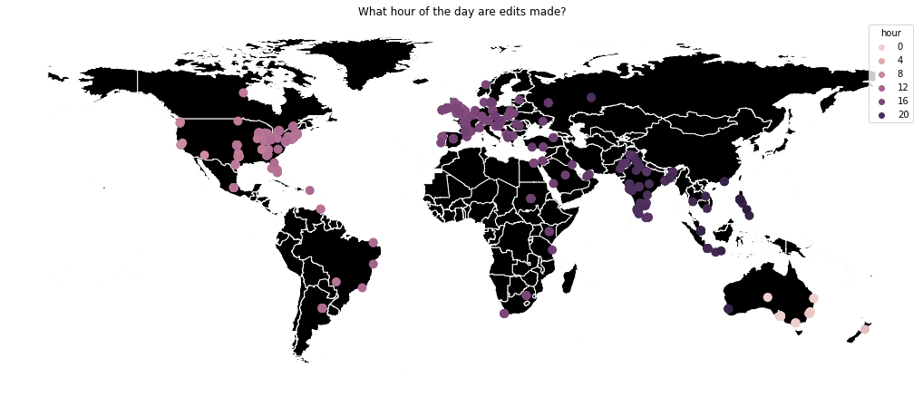

```python
# Plot
geo_plot(dat = tz_df, h = 'hour', t = 'What hour of the day are edits made?')
```

Unfortunately, since the data was taken from a single hour of the day, the all this means is that edits in Australia were made around midnight, West America the early hours and East America, Europe/Asia during the day. This could explain why we are generally seeing more in Europe/Asia. We can confirm using a countplot of the timezone:

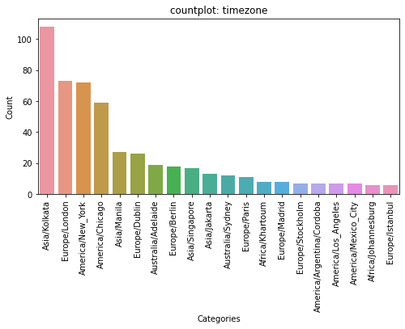

```python
rcParams['figure.figsize'] = 8,4
countplot(data = tz_df, var = 'timezone')
```

We could tentatively conclude that edits are generally made at what we might consider a *reasonable* time during the day and therefore we can more reliably trust the information but it could also simply be that edits are generally made by people from more central time zones (there may also be more people). Without 24hrs of data we can't tell.

### 8. Text Features

Finally, I want to explore whether we can learn anything from the titles of the articles being edited. Firstly, take the title column and do some basic preprocessing:

```python
# Take page titles
text_data = " ".join(title for title in df.page_title.astype(str))

# Replace : with space
text_data = text_data.replace(':',' ')

# Remove punctuation
text_data = text_data.translate(str.maketrans('','',string.punctuation))

# Lower case
text_data = text_data.lower()

# Tokenise
text_data = nltk.word_tokenize(text_data)

# Define stopwords
stopwords = set(STOPWORDS)

# Add some custom stopwords
stopwords.update(['wikipedia','user','edit','special','category','talk','draft',
                 'logdelete','logabusefilter','lognewusers', 'list','file','logmove','wikiproject'])

# View first 5 words
text_data[0:5]
```

```
['josé', 'abad', 'santos', '2021', 'wimbledon']
```

Now view on a wordcloud:

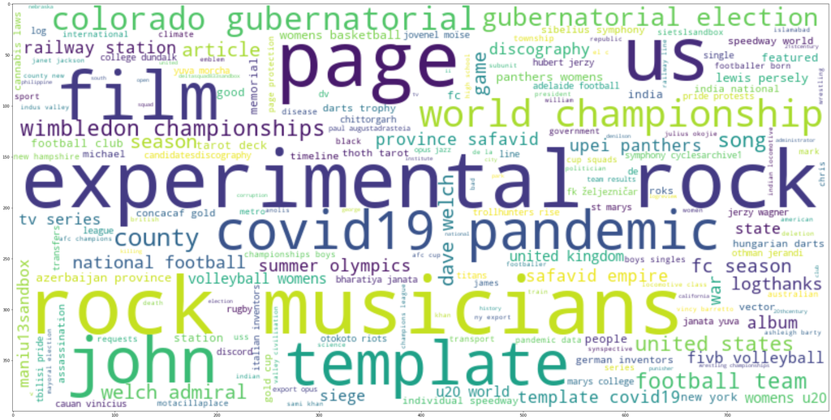

```python
create_wordcloud()
```

Again, most of what I can see looks reasonable as the pages which are being edited seem like current or live events in progress.

As a final conclusion, based on what we can infer from the data, the information on Wikipedia is generally accurate. This is good, since Wikipedia is an encyclopedia and is considered reliably sourced information. If you know where to look, information on the internet is accurate.